# Perforamnce Analysis and Prediction Between CPU and GPU for Machine Learning

## Performance Analysis and Prediction Between

## CPU and GPU for Machine Learning

### **Introduction**

In the realm of machine learning, the selection of appropriate hardware plays a pivotal role in attaining peak performance and efficiency. Among the primary computing devices utilized for machine learning tasks, GPUs and CPUs stand out, each showcasing distinct strengths and weaknesses.

Traditionally, CPUs or central processing units have held the preference owing to their versatility and adeptness in multitasking. CPU acts as the computer's brain, executing fundamental instructions such as arithmetic, logic operations, and I/O tasks. On the other hand, a GPU, or graphics processing unit, designed originally for 2D and 3D graphics and specialized in rendering for high-resolution graphics, but these days with the surge in big data and machine learning applications has propelled GPUs into the spotlight, given their capacity to manage extensive datasets and execute parallel computations.

This project aims to delve into the analysis of the variance between GPU and CPU performance by delving into the specifications of the processors, to determine which processors of CPU or GPU provide superior power for machine learning, also which companies have a higher number in manufacturing in these processors and if there are companies manufacturing both of these processors. The last stage of this project is creating a prediction module on the frequency of these processors, and choosing the model that has the higher accuracy in prediction.

### **About The Dataset**

This dataset has been collected from Kaggle under the CPU and GPU Performances Dataset topic. It contains 2,185 CPUs and 2,668 GPUs to understand the development trend of CPUs and GPUs and their performance. It encompasses a diverse set of benchmarks and metrics like process size, thermal design power(TDP), die size, number of transistors, and frequency to evaluate the performance of these two types of processors. In addition, the release date and the manufacturer to see the evolution of these processors' performance during these years.

#### **Important Terminology**

**1. Process Size (nm):** the size of the transistors used in a processor. The size plays a significant role and typically enables a greater number of transistors to be accommodated within the same physical area (Die Area), potentially leading to enhanced performance, decreased power consumption, and reduced production expenses(nm is an acronym for Nano-meter. It is used to measure microscopic objects or devices like transistors found in processors or atomic structures).

**2. Die Size (mm^2):** In computing, die refers to the piece of silicon of which the processing unit (a GPU or CPU) consists, often called a chip. Die size means the size of the chunk on a silicon wafer that belongs to one chip. Smaller die sizes allow for more transistors to be packed into the same area resulting in higher processing power and also consuming less power. The number and density of transistors packed into the die determine the processor's computational capacity. (mm^2 is a short form for square millimeters).

**3. TDP(W):** the electrical energy usage of a computer chip operating at its maximum theoretical load, measured in watts (W).

**4. Transistors (million):** are minuscule electronic components, that function as switches governing the flow of electricity within a circuit. Within processor architecture, these transistors serve as the foundational elements for constructing logic gates and memory cells, essential components that constitute a processor.

**5. Freq (MHz):** relates to the clock rate or clock speed at which a processor's clock generator can produce pulses to perform operations within a specified time frame, which is the responsibility of the billions of transistors within the processor to produce these pulses. For instance, a processor operating at a clock speed of 3.2 GHz (3200 MHz) completes 3.2 billion cycles per second.

### **Setting up the Libraries**

```python
pip install plotl
```

[output not shown]

```python
pip install --upgrade nbformat
```

```python
import pandas as pd
import numpy as np
import plotly.express as px
from matplotlib import pyplot as plt
import seaborn as sns
from sklearn.feature_selection import SelectKBest, f_regression
from sklearn.model_selection import train_test_split
from sklearn import linear_model
from sklearn.metrics import mean_squared_error, mean_absolute_error, r2_score
from sklearn import preprocessing
from sklearn.preprocessing import StandardScaler
from sklearn.svm import SVR
import plotly.offline as pyo
pyo.init_notebook_mode(connected=True)
```

### **Import The Dataset file called "chip_dataset.csv"**

```python
dataset=pd.read_csv('chip_dataset.csv')
dataset
```

|  | Unnamed: 0 | Product | Type | Release Date | Process Size (nm) | TDP (W) | Die Size (mm^2) | Transistors (million) | Freq (MHz) | Foundry | Vendor | FP16 GFLOPS | FP32 GFLOPS | FP64 GFLOPS |
| --- | --- | --- | --- | --- | --- | --- | --- | --- | --- | --- | --- | --- | --- | --- |
| 0 | 0 | AMD Athlon 64 3500+ | CPU | 2/20/2007 | 65.0 | 45.0 | 77.0 | 122.0 | 2200 | Unknown | AMD | NaN | NaN | NaN |
| 1 | 1 | AMD Athlon 200GE | CPU | 9/6/2018 | 14.0 | 35.0 | 192.0 | 4800.0 | 3200 | Unknown | AMD | NaN | NaN | NaN |
| 2 | 2 | Intel Core i5-1145G7 | CPU | 9/2/2020 | 10.0 | 28.0 | NaN | NaN | 2600 | Intel | Intel | NaN | NaN | NaN |
| 3 | 3 | Intel Xeon E5-2603 v2 | CPU | 9/1/2013 | 22.0 | 80.0 | 160.0 | 1400.0 | 1800 | Intel | Intel | NaN | NaN | NaN |
| 4 | 4 | AMD Phenom II X4 980 BE | CPU | 5/3/2011 | 45.0 | 125.0 | 258.0 | 758.0 | 3700 | Unknown | AMD | NaN | NaN | NaN |
| ... | ... | ... | ... | ... | ... | ... | ... | ... | ... | ... | ... | ... | ... | ... |
| 4849 | 4849 | NVIDIA Quadro 3000M | GPU | 2/22/2011 | 40.0 | 75.0 | 332.0 | 1950.0 | 450 | TSMC | NVIDIA | NaN | 432.0 | 36.0 |
| 4850 | 4850 | Intel GMA 950 | GPU | 6/1/2005 | 90.0 | 7.0 | NaN | NaN | 250 | Intel | Intel | NaN | NaN | NaN |
| 4851 | 4851 | NVIDIA GeForce GT 320M | GPU | 3/3/2010 | 40.0 | 23.0 | 100.0 | 486.0 | 500 | TSMC | NVIDIA | NaN | 52.8 | NaN |
| 4852 | 4852 | NVIDIA GeForce FX 5200 | GPU | 3/6/2003 | 150.0 | NaN | 65.0 | 29.0 | 250 | TSMC | NVIDIA | NaN | NaN | NaN |
| 4853 | 4853 | NVIDIA GeForce 9300 SE | GPU | 6/1/2008 | 65.0 | NaN | 86.0 | 210.0 | 540 | TSMC | NVIDIA | NaN | 20.8 | NaN |

4854 rows × 14 columns

### **Data Cleaning and Processing**

This stage is considered a fundamental stage in data analysis because when working with a real-world problem, there is no documentation of the data and the dataset is messy. To improve the quality of the data and to make it more suitable for analysis we have to clean the data by identifying and correcting or removing errors, inconsistencies, and missing values from a dataset and then preprocessing to transform and prepare the data for analysis and prediction.

#### **Explore the Data**

Using the describe method to get overall summary of the dataset. It will return count,mean, std,25th and 75th quartiles,min and max.

```python
dataset.describe()
```

|  | Unnamed: 0 | Process Size (nm) | TDP (W) | Die Size (mm^2) | Transistors (million) | Freq (MHz) | FP16 GFLOPS | FP32 GFLOPS | FP64 GFLOPS |
| --- | --- | --- | --- | --- | --- | --- | --- | --- | --- |
| count | 4854.000000 | 4845.000000 | 4228.000000 | 4139.000000 | 4143.000000 | 4854.000000 | 536.000000 | 1948.000000 | 1306.000000 |
| mean | 2426.500000 | 55.109598 | 81.359981 | 188.440445 | 1929.922279 | 1484.406057 | 8397.459851 | 2134.756653 | 363.670511 |
| std | 1401.373433 | 44.998676 | 76.807808 | 126.189383 | 4044.891098 | 1066.701523 | 13799.551131 | 3898.431487 | 1145.931856 |
| min | 0.000000 | 0.000000 | 1.000000 | 1.000000 | 8.000000 | 100.000000 | 10.020000 | 12.800000 | 3.600000 |
| 25% | 1213.250000 | 22.000000 | 33.000000 | 104.000000 | 154.000000 | 590.000000 | 768.800000 | 257.300000 | 38.295000 |
| 50% | 2426.500000 | 40.000000 | 65.000000 | 148.000000 | 624.000000 | 1073.500000 | 2965.500000 | 696.000000 | 89.280000 |
| 75% | 3639.750000 | 90.000000 | 100.000000 | 239.000000 | 1550.000000 | 2400.000000 | 10600.000000 | 2116.750000 | 220.000000 |
| max | 4853.000000 | 250.000000 | 900.000000 | 826.000000 | 54200.000000 | 4700.000000 | 184600.000000 | 40000.000000 | 11540.000000 |

Then use the duplicated method with the sum function to return the total value of rows in the DataFrame that are duplicated.

```python
dataset.duplicated().sum()
```

```
0
```

#### **Check and Handling Missing Values,Drop and Rename Columns**

```python
# To calculate the number of missing values in every column.
dataset.isna().sum()
```

```
Unnamed: 0                  0
Product                     0
Type                        0
Release Date                0
Process Size (nm)           9
TDP (W)                   626
Die Size (mm^2)           715
Transistors (million)     711
Freq (MHz)                  0
Foundry                     0
Vendor                      0
FP16 GFLOPS              4318
FP32 GFLOPS              2906
FP64 GFLOPS              3548
dtype: int64
```

Two ways to handle the missing values drop rows with missing values or replace them with the mean or mode.

##### **Drop Columns**

The columns FP16, FP32, and FP64 GFLOPS have too many missing values especially if they do have not any value to CPU only for GPU which is significant for comparing them, and for the Foundry column, also has many missing values as well, and since we have a Vendor column which is kind of the same info present it for us to use. finally, dropping column Unnamed: 0 because it does not add any value to our data.

```python
dataset.drop(["Unnamed: 0","Foundry","FP16 GFLOPS","FP32 GFLOPS","FP64 GFLOPS"],axis="columns",inplace=True)
dataset
```

|  | Product | Type | Release Date | Process Size (nm) | TDP (W) | Die Size (mm^2) | Transistors (million) | Freq (MHz) | Vendor |
| --- | --- | --- | --- | --- | --- | --- | --- | --- | --- |
| 0 | AMD Athlon 64 3500+ | CPU | 2/20/2007 | 65.0 | 45.0 | 77.0 | 122.0 | 2200 | AMD |
| 1 | AMD Athlon 200GE | CPU | 9/6/2018 | 14.0 | 35.0 | 192.0 | 4800.0 | 3200 | AMD |
| 2 | Intel Core i5-1145G7 | CPU | 9/2/2020 | 10.0 | 28.0 | NaN | NaN | 2600 | Intel |
| 3 | Intel Xeon E5-2603 v2 | CPU | 9/1/2013 | 22.0 | 80.0 | 160.0 | 1400.0 | 1800 | Intel |
| 4 | AMD Phenom II X4 980 BE | CPU | 5/3/2011 | 45.0 | 125.0 | 258.0 | 758.0 | 3700 | AMD |
| ... | ... | ... | ... | ... | ... | ... | ... | ... | ... |
| 4849 | NVIDIA Quadro 3000M | GPU | 2/22/2011 | 40.0 | 75.0 | 332.0 | 1950.0 | 450 | NVIDIA |
| 4850 | Intel GMA 950 | GPU | 6/1/2005 | 90.0 | 7.0 | NaN | NaN | 250 | Intel |
| 4851 | NVIDIA GeForce GT 320M | GPU | 3/3/2010 | 40.0 | 23.0 | 100.0 | 486.0 | 500 | NVIDIA |
| 4852 | NVIDIA GeForce FX 5200 | GPU | 3/6/2003 | 150.0 | NaN | 65.0 | 29.0 | 250 | NVIDIA |
| 4853 | NVIDIA GeForce 9300 SE | GPU | 6/1/2008 | 65.0 | NaN | 86.0 | 210.0 | 540 | NVIDIA |

4854 rows × 9 columns

##### **Rename Columns**

We need to rename the columns to make it easier and more clear when calling them.

```python
dataset.columns = ["Product","Type", "Release Date", "Process Size (nm)", "TDP (W)", "Die Size (mm^2)", "Transistors (million)", "Frequency (GHz)", "Company"]
dataset
```

|  | Product | Type | Release Date | Process Size (nm) | TDP (W) | Die Size (mm^2) | Transistors (million) | Frequency (GHz) | Company |
| --- | --- | --- | --- | --- | --- | --- | --- | --- | --- |
| 0 | AMD Athlon 64 3500+ | CPU | 2/20/2007 | 65.0 | 45.0 | 77.0 | 122.0 | 2200 | AMD |
| 1 | AMD Athlon 200GE | CPU | 9/6/2018 | 14.0 | 35.0 | 192.0 | 4800.0 | 3200 | AMD |
| 2 | Intel Core i5-1145G7 | CPU | 9/2/2020 | 10.0 | 28.0 | NaN | NaN | 2600 | Intel |
| 3 | Intel Xeon E5-2603 v2 | CPU | 9/1/2013 | 22.0 | 80.0 | 160.0 | 1400.0 | 1800 | Intel |
| 4 | AMD Phenom II X4 980 BE | CPU | 5/3/2011 | 45.0 | 125.0 | 258.0 | 758.0 | 3700 | AMD |
| ... | ... | ... | ... | ... | ... | ... | ... | ... | ... |
| 4849 | NVIDIA Quadro 3000M | GPU | 2/22/2011 | 40.0 | 75.0 | 332.0 | 1950.0 | 450 | NVIDIA |
| 4850 | Intel GMA 950 | GPU | 6/1/2005 | 90.0 | 7.0 | NaN | NaN | 250 | Intel |
| 4851 | NVIDIA GeForce GT 320M | GPU | 3/3/2010 | 40.0 | 23.0 | 100.0 | 486.0 | 500 | NVIDIA |
| 4852 | NVIDIA GeForce FX 5200 | GPU | 3/6/2003 | 150.0 | NaN | 65.0 | 29.0 | 250 | NVIDIA |
| 4853 | NVIDIA GeForce 9300 SE | GPU | 6/1/2008 | 65.0 | NaN | 86.0 | 210.0 | 540 | NVIDIA |

4854 rows × 9 columns

In this step, renaming the unit name of the frequency from megahertz to gigahertz because we are dealing with frequencies of modern processors. In the next step, we will change the unit from megahertz to gigahertz.

```python
dataset['Frequency (GHz)'] = round(dataset['Frequency (GHz)'] / 1000, 1)
dataset['Frequency (GHz)']
```

```
0       2.2
1       3.2
2       2.6
3       1.8
4       3.7
       ...
4849    0.4
4850    0.2
4851    0.5
4852    0.2
4853    0.5
Name: Frequency (GHz), Length: 4854, dtype: float64
```

##### **Handling the Missing Values**

```python
# To calculate the number of missing values in every column agian after drop and rename columns.
dataset.isna().sum()
```

```
Product                    0
Type                       0
Release Date               0
Process Size (nm)          9
TDP (W)                  626
Die Size (mm^2)          715
Transistors (million)    711
Frequency (GHz)            0
Company                    0
dtype: int64
```

Since the total missing is around 30% so we have to use the replacing missing values. To use this method missing data should be numeric or categorical value data for replacing them with the mean or mode.

I have decided to proceed with the mean solution to replace the missing values. To fill the missing values by mean, I had to take the average separately for each of these columns (TDP (W), Die Size (mm^2), Transistors (million)) grouped by type of processor (CPU, GPU) to make it more accurate.

##### **TDP (W)**

```python
# Take the average of TDP (W) grouped by Type and put it in a variable.
TDP_AVG = dataset.groupby('Type').agg(avg_tdp=('TDP (W)', 'mean')).reset_index()
print(TDP_AVG)

# Create variable to take the CPU (TDP (W)) average only.
cpu_tdp = TDP_AVG.loc[TDP_AVG['Type'] == 'CPU', 'avg_tdp'].values[0]
print(cpu_tdp)

# Create variable to take the GPU (TDP (W)) average only.
gpu_tdp = TDP_AVG.loc[TDP_AVG['Type'] == 'GPU', 'avg_tdp'].values[0]
print(gpu_tdp)

# Replace missing values with the group mean (TDP (W)) of each type of processor.
dataset['TDP (W)'] = dataset.apply(lambda row: cpu_tdp if pd.isna(row['TDP (W)']) and row['Type'] == 'CPU' else (gpu_tdp if pd.isna(row['TDP (W)']) and row['Type'] == 'GPU' else row['TDP (W)']), axis=1)
```

```
  Type    avg_tdp
0  CPU  75.402372
1  GPU  87.774067
75.40237226277372
87.77406679764243
```

#### **Die Size (mm^2)**

```python
# Take the average of Die Size (mm^2) grouped by Type and put it in a variable.
Die_AVG = dataset.groupby('Type').agg(avg_die=('Die Size (mm^2)', 'mean')).reset_index()
print(Die_AVG)

# Create variable to take the CPU Die Size (mm^2) average only.
cpu_die = Die_AVG.loc[Die_AVG['Type'] == 'CPU', 'avg_die'].values[0]
print(cpu_die)

# Create variable to take the GPU Die Size (mm^2) average only.
gpu_die = Die_AVG.loc[Die_AVG['Type'] == 'GPU', 'avg_die'].values[0]
print(gpu_die)

# Replace missing values with the group mean Die Size (mm^2) of each type of processor.
dataset['Die Size (mm^2)'] = dataset.apply(lambda row: cpu_die if pd.isna(row['Die Size (mm^2)']) and row['Type'] == 'CPU' else (gpu_die if pd.isna(row['Die Size (mm^2)']) and row['Type'] == 'GPU' else row['Die Size (mm^2)']), axis=1)
```

```
  Type     avg_die
0  CPU  166.506024
1  GPU  203.128278
166.50602409638554
203.1282775312626
```

#### **Transistors (million)**

```python
# Take the average of Transistors (million) grouped by Type and put it in a variable.
TS_AVG = dataset.groupby('Type').agg(avg_ts=('Transistors (million)', 'mean')).reset_index()
print(TS_AVG)

# Create variable to take the CPU Transistors (million) average only.
cpu_ts = TS_AVG.loc[TS_AVG['Type'] == 'CPU', 'avg_ts'].values[0]
print(cpu_ts)


# Create variable to take the GPU Transistors (million) average only.
gpu_ts = TS_AVG.loc[TS_AVG['Type'] == 'GPU', 'avg_ts'].values[0]
print(gpu_ts)

# Replace missing values with the group mean Transistors (million) of each type of processor.
dataset['Transistors (million)'] = dataset.apply(lambda row: cpu_ts if pd.isna(row['Transistors (million)']) and row['Type'] == 'CPU' else (gpu_ts if pd.isna(row['Transistors (million)']) and row['Type'] == 'GPU'
else row['Transistors (million)']), axis=1)
```

```
  Type       avg_ts
0  CPU  1156.340299
1  GPU  2454.942464
1156.3402985074626
2454.9424635332252
```

```python
# To calculate the number of missing values in every column after handeking the missing values in ((TDP (W), Die Size (mm^2), Transistors (million))).
dataset.isna().sum()
```

```
Product                  0
Type                     0
Release Date             0
Process Size (nm)        9
TDP (W)                  0
Die Size (mm^2)          0
Transistors (million)    0
Frequency (GHz)          0
Company                  0
dtype: int64
```

#### **Delete Rows**

The remaining nine missing values are too small to affect the data, so the best way to handle them is by dropping these rows by the drop_na function.

```python
dataset.dropna(inplace=True)
```

```python
# The last check on missing values in the data set
dataset.isna().sum()
```

```
Product                  0
Type                     0
Release Date             0
Process Size (nm)        0
TDP (W)                  0
Die Size (mm^2)          0
Transistors (million)    0
Frequency (GHz)          0
Company                  0
dtype: int64
```

#### **Check Dataset Format**

The last step in Data Cleaning and Processing is to check the dataset format before proceeding to Data Analysis and Prediction.

```python
# To check every column type
dataset.dtypes
```

```
Product                   object
Type                      object
Release Date              object
Process Size (nm)        float64
TDP (W)                  float64
Die Size (mm^2)          float64
Transistors (million)    float64
Frequency (GHz)          float64
Company                   object
dtype: object
```

```python
dataset['Release Date'] = pd.to_datetime(dataset['Release Date'], format='%m/%d/%Y')
```

#### **Add Columns**

Create new column called Transistor Density to calculate the number of transistors per square millimeter on a chip.

```python
dataset['Transistor Density'] = round((dataset['Transistors (million)'] * 1000000)  / dataset['Die Size (mm^2)'],2)
```

Create a new column as well named Year, so that we can use this column when looking for trends over time.

```python
dataset['Year'] = dataset['Release Date'].dt.year.astype('Int64')
```

```python
# Check again all the formats
dataset.dtypes
```

```
Product                          object
Type                             object
Release Date             datetime64[ns]
Process Size (nm)               float64
TDP (W)                         float64
Die Size (mm^2)                 float64
Transistors (million)           float64
Frequency (GHz)                 float64
Company                          object
Transistor Density              float64
Year                              Int64
dtype: object
```

```python
# Check NA values after formatting
dataset.isna().sum()
```

```
Product                   0
Type                      0
Release Date             72
Process Size (nm)         0
TDP (W)                   0
Die Size (mm^2)           0
Transistors (million)     0
Frequency (GHz)           0
Company                   0
Transistor Density        0
Year                     72
dtype: int64
```

After formatting the date, we explore more NA values in the date column, and because the number is too small to affect, we will drop these rows.

```python
dataset = dataset.dropna()
```

Finally, we need to check if there are any zero values in our dataset.

```python
np.sum(dataset == 0, axis=0)
```

```
Product                  0
Type                     0
Release Date             0
Process Size (nm)        4
TDP (W)                  0
Die Size (mm^2)          0
Transistors (million)    0
Frequency (GHz)          0
Company                  0
Transistor Density       0
Year                     0
dtype: Int64
```

```python
# Viewing the product that has zero processor
dataset[dataset['Process Size (nm)'] == 0]
```

|  | Product | Type | Release Date | Process Size (nm) | TDP (W) | Die Size (mm^2) | Transistors (million) | Frequency (GHz) | Company | Transistor Density | Year |
| --- | --- | --- | --- | --- | --- | --- | --- | --- | --- | --- | --- |
| 2239 | Matrox QID LP PCIe | GPU | 2004-12-17 | 0.0 | 87.774067 | 203.128278 | 2454.942464 | 0.2 | Other | 12085675.58 | 2004 |
| 3402 | Matrox QID PRO | GPU | 2004-12-17 | 0.0 | 87.774067 | 203.128278 | 2454.942464 | 0.2 | Other | 12085675.58 | 2004 |
| 3882 | Matrox QID | GPU | 2004-12-17 | 0.0 | 87.774067 | 203.128278 | 2454.942464 | 0.2 | Other | 12085675.58 | 2004 |
| 4249 | Matrox QID LP PCI | GPU | 2004-12-17 | 0.0 | 87.774067 | 203.128278 | 2454.942464 | 0.2 | Other | 12085675.58 | 2004 |

There is something wrong with these products information, they have the same values in all columns even though they are different products. The optimal solution is to drop these rows.

```python
dataset = dataset[dataset['Process Size (nm)'] != 0]
```

```python
# Viewing the data after Data Cleaning and Processing
dataset
```

|  | Product | Type | Release Date | Process Size (nm) | TDP (W) | Die Size (mm^2) | Transistors (million) | Frequency (GHz) | Company | Transistor Density | Year |
| --- | --- | --- | --- | --- | --- | --- | --- | --- | --- | --- | --- |
| 0 | AMD Athlon 64 3500+ | CPU | 2007-02-20 | 65.0 | 45.000000 | 77.000000 | 122.000000 | 2.2 | AMD | 1584415.58 | 2007 |
| 1 | AMD Athlon 200GE | CPU | 2018-09-06 | 14.0 | 35.000000 | 192.000000 | 4800.000000 | 3.2 | AMD | 25000000.00 | 2018 |
| 2 | Intel Core i5-1145G7 | CPU | 2020-09-02 | 10.0 | 28.000000 | 166.506024 | 1156.340299 | 2.6 | Intel | 6944735.51 | 2020 |
| 3 | Intel Xeon E5-2603 v2 | CPU | 2013-09-01 | 22.0 | 80.000000 | 160.000000 | 1400.000000 | 1.8 | Intel | 8750000.00 | 2013 |
| 4 | AMD Phenom II X4 980 BE | CPU | 2011-05-03 | 45.0 | 125.000000 | 258.000000 | 758.000000 | 3.7 | AMD | 2937984.50 | 2011 |
| ... | ... | ... | ... | ... | ... | ... | ... | ... | ... | ... | ... |
| 4849 | NVIDIA Quadro 3000M | GPU | 2011-02-22 | 40.0 | 75.000000 | 332.000000 | 1950.000000 | 0.4 | NVIDIA | 5873493.98 | 2011 |
| 4850 | Intel GMA 950 | GPU | 2005-06-01 | 90.0 | 7.000000 | 203.128278 | 2454.942464 | 0.2 | Intel | 12085675.58 | 2005 |
| 4851 | NVIDIA GeForce GT 320M | GPU | 2010-03-03 | 40.0 | 23.000000 | 100.000000 | 486.000000 | 0.5 | NVIDIA | 4860000.00 | 2010 |
| 4852 | NVIDIA GeForce FX 5200 | GPU | 2003-03-06 | 150.0 | 87.774067 | 65.000000 | 29.000000 | 0.2 | NVIDIA | 446153.85 | 2003 |
| 4853 | NVIDIA GeForce 9300 SE | GPU | 2008-06-01 | 65.0 | 87.774067 | 86.000000 | 210.000000 | 0.5 | NVIDIA | 2441860.47 | 2008 |

4769 rows × 11 columns

### **Data Visualization and Analysis**

Data visualization is the graphical representation of a dataset in a pictorial format. It is a way to see and understand trends, patterns in data, and outliers. Data visualization is essential to the Analysis for discovering useful information and making findings before prediction.

#### **Types of Processors**

```python
data_for_plot = dataset.groupby('Type').size().reset_index(name='Count')

fig = px.pie(data_for_plot, names="Type", values="Count", color_discrete_sequence=["#ffa500", "#0a75ad"])

fig.update_layout(title_text="CPU vs GPU Count Unit", title_x=0.5, title_y=0.98, autosize=False, width=800, height=500)

# Use pyo.iplot to display the figure inline
pyo.iplot(fig)
```

[interactive chart not shown]

#### **Comparison Between Companies**

```python
data_for_plot2 = dataset.groupby(['Type', 'Company']).size().reset_index(name='Count')

fig = px.bar(data_for_plot2, x='Company', y='Count', color='Type',
             text='Count', barmode='group',
             color_discrete_sequence=["#ffa500", "#0a75ad"])

fig.update_traces(textposition='outside')
fig.update_layout(title_text="CPU and GPU Count Between Companies",
                  xaxis_title="Company", yaxis_title="Count",
                  xaxis=dict(tickmode='linear'),
                  yaxis=dict(tickmode='array', tickvals=[500, 1000, 1500], ticktext=[500, 1000, 1500]),
                  legend=dict(title="Type"),
                  title=dict(x=0.5, y=0.95, xanchor='center', yanchor='top'),
                  legend_title=dict(text='Type'),
                  autosize=False, width=800, height=500)

# Use pyo.iplot to display the figure inline
pyo.iplot(fig)
```

[interactive chart not shown]

This graph shows us the numbers of CPU and GPU between companies. As we can see, there are two companies (AMD, Intel) manufacturing CPU and GPU, the others manufacturing only GPU. After looking at this graph, we see Intel and Nvidia taking the lead in making processors, Intel in CPU, and Nvidia in GPU, and there is AMD which I consider also a competitor for these companies because it comes as number two after Intel in CPU manufacturing and number two after NVIDIA in GPU manufacturing.

#### **The Development of CPUs and GPUs Over Time**

[output not shown]

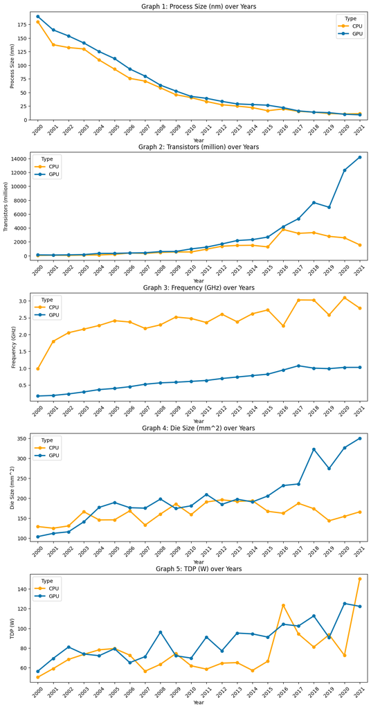

```python
fig,ax =plt.subplots(nrows=5,figsize=(12,24),gridspec_kw={'hspace':0.3})
num_col = ["Process Size (nm)", "Transistors (million)", "Frequency (GHz)", "Die Size (mm^2)","TDP (W)" ]
for i,col in enumerate(num_col):
    sns.pointplot(x="Year", y=col, data= dataset,errorbar=None,ax=ax[i],hue="Type",scale=0.9, palette=["#ffa500", "#0a75ad"])
    ax[i].set_xticklabels(ax[i].get_xticklabels(), rotation=45)
    ax[i].set_title(f"Graph {i + 1}: {col} over Years", fontsize=12)
plt.show()
```

**First Graph:** The Process Size for CPU and GPU evolved similarly with no significant distinction between the two. When we get a closer look at the decade (2000-2010) witness tremendous development compared to the period that followed 2010. However, the overall trend is on consistent decrease in Process Size over time. That is a sign of the integration of more advanced technologies, enabling to achievement of smaller Process Sizes to enhance performance.

**Third Graph:** Looking at this graph for the Frequencies, we can see the big difference in performance between CPUs compared to GPUs with clear superiority CPUs over GPUs. However, both Processing unit seems to have had good development over the years, but the GPUs' improvement is more consistent than the CPUs. Perhaps on this level, GPUs will outperform CPUs in the future in Frequencies.

#### **Transistor Density and Frequency (GHz) - Frequency (GHz) and TDP (W) Over Time**

```python
fig = px.scatter(dataset, x="Year", y="Transistor Density", color="TDP (W)", size="Frequency (GHz)" ,facet_col="Type", height=400, width=800, opacity=0.4, facet_col_wrap=1,
                 title="Transistor Density and Frequency (GHz) Over Time")

fig.update_traces(marker=dict(line=dict(color='white', width=0.4)))

fig.update_layout(autosize=False, width=1200, height=900,title=dict(x=0.5, y=0.95, xanchor='center', yanchor='top'))
```

[interactive chart not shown]

As we can see, the Transistor Density can affect Frequency, TDP (W), or both. Over the years these two processors have evolved to generate the best performance with the best power consumption. Often one feature is developed over another. For example, we see some pieces developed in terms of power at the expense of energy consumption and vice versa. Some products evolved in both energy and performance but did not reach the peak of the products that evolved from one side, but I believe they are the best option as they give everything balanced in terms of performance and energy consumption. We also notice a clear superiority of the CPU over the GPU in terms of performance and energy consumption in general. In recent years, there has been a convergence between processors, and in particular, the GPU is developing steadily so that it is approaching the CPU and may pass it in the future.

**Note:**  
In the graph in section GPU there is an outlier belonging to the product Sony Playstation Vita GPU. I had to check the number of transistors, and unfortunately, there is no available information about it, so I had to drop this value.  
Refrences I checked:  
https://www.techpowerup.com/gpu-specs/playstation-vita-gpu.c3711  
https://img2.topcpu.net/en/cpu/playstation-vita-gpu?lang

```python
dataset = dataset[dataset['Product'] != 'Sony Playstation Vita GPU']
```

```python
condition1 = dataset['Frequency (GHz)'] ==2.3
condition2 = dataset['Frequency (GHz)'] ==2.2
combined_condition = condition1 | condition2
result = dataset[combined_condition]
fig = px.scatter(result, x="Year", y="Transistor Density", color="TDP (W)", size="Frequency (GHz)" ,facet_col="Type", height=400, width=800, opacity=0.4, facet_col_wrap=1,
                 title="Transistor Density and Frequency (GHz) Over Time")

fig.update_traces(marker=dict(line=dict(color='white', width=0.4)))

fig.update_layout(autosize=False, width=1200, height=900,title=dict(x=0.5, y=0.95, xanchor='center', yanchor='top'))
```

[interactive chart not shown]

This graph shows only frequencies of 2.2 and 2.3 GHz to clarify how GPU evolved and kind of reached the CPU performance and power consumption through these years, yes still CPU taking over in general but it is considered a huge jump for the GPU.

### **Predictive Analysis**

#### **Extract The Dependent Variable**

It is the variable we want to predict, also called **Regressor**.

```python
Data_Y = dataset['Frequency (GHz)']
Data_Y.head(10)
```

```
0    2.2
1    3.2
2    2.6
3    1.8
4    3.7
5    2.4
6    2.4
7    3.0
8    2.0
9    2.2
Name: Frequency (GHz), dtype: float64
```

#### **Extract The Independent Variable**

```python
label_encoder = preprocessing.LabelEncoder()
dataset['Type']= label_encoder.fit_transform(dataset['Type'])
```

```python
Data_X  = dataset.loc[:,["Type","Process Size (nm)",'TDP (W)' ,"Die Size (mm^2)", "Transistors (million)", "Transistor Density","Year"]]
Data_X.columns
Data_X.head(10)
```

|  | Type | Process Size (nm) | TDP (W) | Die Size (mm^2) | Transistors (million) | Transistor Density | Year |
| --- | --- | --- | --- | --- | --- | --- | --- |
| 0 | 0 | 65.0 | 45.0 | 77.000000 | 122.000000 | 1584415.58 | 2007 |
| 1 | 0 | 14.0 | 35.0 | 192.000000 | 4800.000000 | 25000000.00 | 2018 |
| 2 | 0 | 10.0 | 28.0 | 166.506024 | 1156.340299 | 6944735.51 | 2020 |
| 3 | 0 | 22.0 | 80.0 | 160.000000 | 1400.000000 | 8750000.00 | 2013 |
| 4 | 0 | 45.0 | 125.0 | 258.000000 | 758.000000 | 2937984.50 | 2011 |
| 5 | 0 | 22.0 | 95.0 | 160.000000 | 1400.000000 | 8750000.00 | 2013 |
| 6 | 0 | 65.0 | 125.0 | 285.000000 | 450.000000 | 1578947.37 | 2008 |
| 7 | 0 | 65.0 | 130.0 | 140.000000 | 376.000000 | 2685714.29 | 2006 |
| 8 | 0 | 10.0 | 28.0 | 166.506024 | 1156.340299 | 6944735.51 | 2020 |
| 9 | 0 | 90.0 | 89.0 | 156.000000 | 154.000000 | 987179.49 | 2006 |